```r
knitr::opts_chunk$set(warning = FALSE, message = FALSE, error = FALSE)
```

### *Aluno: Gustavo Finger*

### *Data: 09/02/2025*

### *Curso Alura/Unibb - Estática com R - Crie e Compare Modelos Estatísticos*

### *Instrutor Alura: Vinícius Barros Rodrigues*

### Passos iniciais

- Instalar as biliotecas apontadas.
- Carregar as bibliotecas.

```r
#install.packages('Ecdat') # caso não esteja instalado ainda a biblioteca
library(Ecdat) # chamada da bilbioteca para uso
data(Airq) # banco de dados da biblioteca
names(Airq) # exibe o nome das variáveis
```

```
[1] "airq" "vala" "rain" "coas" "dens" "medi"
```

```r
# Análise descritiva destes dados
summary(Airq) # resumo das variáveis.
```

```
      airq            vala              rain        coas
 Min.   : 59.0   Min.   :  992.9   Min.   :12.63   no : 9
 1st Qu.: 81.0   1st Qu.: 1535.8   1st Qu.:31.02   yes:21
 Median :114.0   Median : 2629.8   Median :36.66
 Mean   :104.7   Mean   : 4188.5   Mean   :36.08
 3rd Qu.:126.2   3rd Qu.: 4141.4   3rd Qu.:42.70
 Max.   :165.0   Max.   :19733.8   Max.   :68.13
      dens              medi
 Min.   :  271.6   Min.   :  853
 1st Qu.:  365.2   1st Qu.: 3340
 Median :  796.2   Median : 4858
 Mean   : 1728.6   Mean   : 9477
 3rd Qu.: 1635.2   3rd Qu.: 8715
 Max.   :12957.5   Max.   :59460
```

# Descrevendo as variáveis

airq: índice de qualidade do ar (quando menor, melhor)

vala: Valor das empresas nas cidades (em milhares de doláres)

rain: quantidade de chuva (em polegadas)

coas: posição costeira da cidade (sim ou não)

den: denisdade populacional (pessoas por milha_quadrada)

medi: renda média per capita (Em doláres)

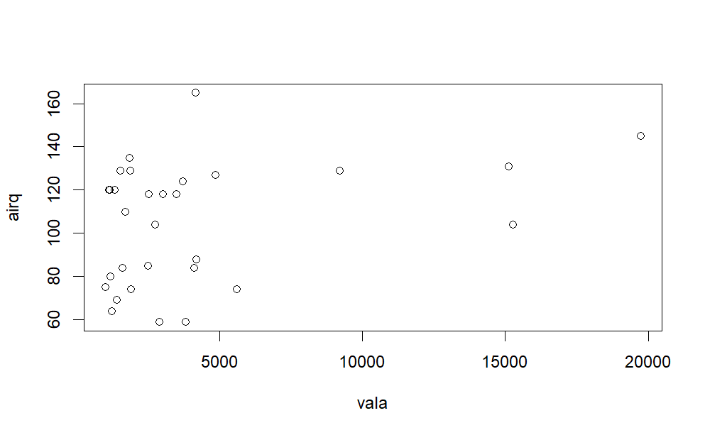

```r
# variáveis podem ser contínuas ou categóricas.

plot(airq~vala, data= Airq) # o ~ representa em função "Airq em função de Vala"
```

```r
# Montando o Modelo
m1<-lm(airq~vala, data=Airq) # lm (modelo linear)

# alguns dados podem não ser lineares
m1
```

```
Call:
lm(formula = airq ~ vala, data = Airq)

Coefficients:
(Intercept)         vala
  96.451419     0.001969
```

```r
summary(m1) # para saber a significancia
```

```
Call:
lm(formula = airq ~ vala, data = Airq)

Residuals:
    Min      1Q  Median      3Q     Max
-44.970 -22.002   7.228  20.774  60.361

Coefficients:
             Estimate Std. Error t value Pr(>|t|)
(Intercept) 96.451419   6.691801  14.413 1.76e-14 ***
vala         0.001969   0.001082   1.821   0.0794 .
---
Signif. codes:  0 ‘***’ 0.001 ‘**’ 0.01 ‘*’ 0.05 ‘.’ 0.1 ‘ ’ 1

Residual standard error: 26.97 on 28 degrees of freedom
Multiple R-squared:  0.1058,    Adjusted R-squared:  0.07391
F-statistic: 3.314 on 1 and 28 DF,  p-value: 0.07938
```

```r
# o p-valor indica a dignificancia do modelo ou da váriavel
# se o p-valor < 0.05 é significante. Isto é, existe um efeito
# se o p-valor > 0.05 Não é significante. Isto é, não existe um efeito

# A variável vala não influenciou a qualidade do ar nas cidades.
```

A variável vala não influenciou a qualidade do ar nas cidades.

# Vamos analisar as outras variáveis influenciando a qualidade do ar

```r
m2<-lm(airq~coas, data=Airq)
m2
```

```
Call:
lm(formula = airq ~ coas, data = Airq)

Coefficients:
(Intercept)      coasyes
     125.33       -29.48
```

```r
# A Variável Coas afeta a váriavel "Airq"
summary(m2)
```

```
Call:
lm(formula = airq ~ coas, data = Airq)

Residuals:
    Min      1Q  Median      3Q     Max
-36.857 -15.726  -6.333  17.167  69.143

Coefficients:
            Estimate Std. Error t value Pr(>|t|)
(Intercept)  125.333      8.288  15.123 5.32e-15 ***
coasyes      -29.476      9.906  -2.976  0.00596 **
---
Signif. codes:  0 ‘***’ 0.001 ‘**’ 0.01 ‘*’ 0.05 ‘.’ 0.1 ‘ ’ 1

Residual standard error: 24.86 on 28 degrees of freedom
Multiple R-squared:  0.2403,    Adjusted R-squared:  0.2131
F-statistic: 8.855 on 1 and 28 DF,  p-value: 0.005965
```

#plotando m2

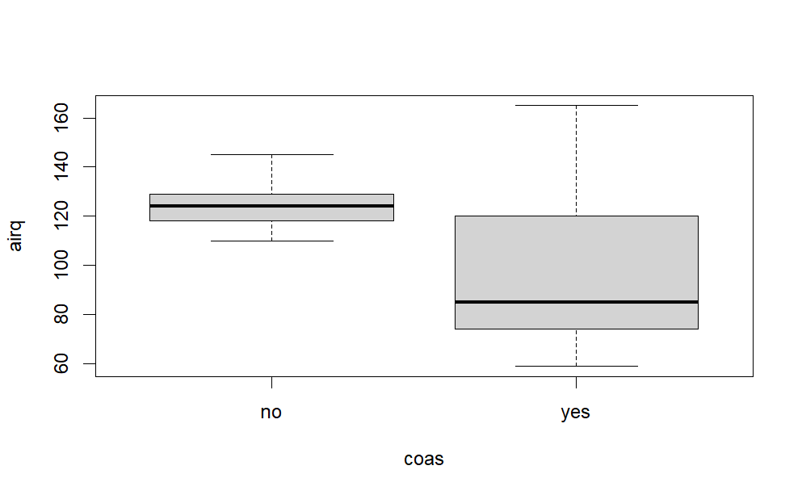

```r
plot(airq~coas, data= Airq)
```

Percebemos que as cidades costeiras apresentam uma melhor qualidade do ar.

```r
m3<-lm(airq~medi, data=Airq)
summary(m3)
```

[output not shown]

A variável medi não interfere na qualidade do ar.

#plotando m3

```r
plot(airq~medi, data= Airq)
```

[output not shown]

### A quantidade de chuva influencia na qualidade do ar?

```r
m4<-lm(airq~rain, data=Airq)
summary(m4)
```

[output not shown]

### não, vamos plotar

```r
plot(airq~rain, data= Airq)
```

[output not shown]

### Como adicionar as retas no gráficos?

y= a + b*x # equação da reta

‘b’ é inclinção da reta

‘x’ é a variável explicativa

‘a’ onde a reta irá tocar no eixo y - interecept

```r
summary(m3) # para pegar os valores da reta
```

[output not shown]

# melhorar o gráfico.

```r
plot(airq~medi, data= Airq, xlab='Renda média per Capita', ylab='Qualidade do ar', pch=1, col='Blue',
     cex.lab=1.1,main='Renda média - 2010')
curve(9.936e+01+5.638e-04*x,add=TRUE, col='darkBlue',lwd=2, lty=2)
```

[output not shown]

#melhorando ainda mais os gráficos.

```r
plot(airq~coas, data= Airq, xlab='Posição Costeira', ylab='Qualidade do ar',     col='lightblue',
     main= 'Análise da qualidade do ar')
```

[output not shown]

#modelo de regressão múltipla, Em um modelo de regressão múltipla, a variável dependente (Y) será determinada por mais de uma variável independente (X).

```r
m_R_m1<-lm(airq~vala+coas, data=Airq)
summary(m_R_m1)
```

[output not shown]

# Gráfico Regressão Múltipla

```r
plot(airq~vala, data= Airq,xlab='Valor das Empresa $', ylab='Qualidade do ar')
curve(1.171e+02+  1.999e-03*x,add=TRUE) # cidade não costeiras
```

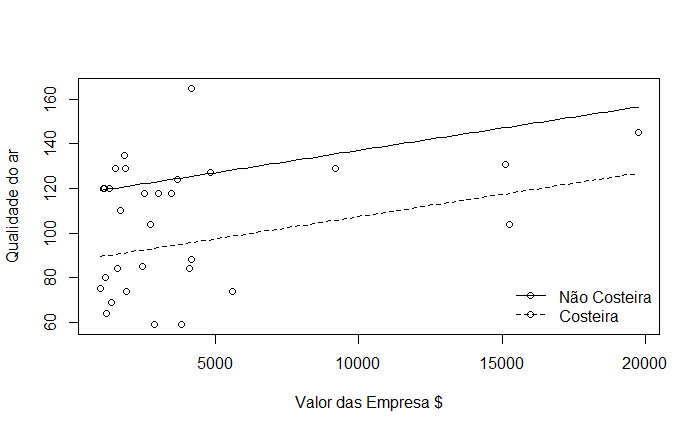

```r
curve(1.171e+02+  1.999e-03*x+-2.968e+01,lty =2, add = TRUE) # cidade costeira
legend("bottomright",c('Não Costeira', 'Costeira'),pch=1,lty=c(1,2), bty="n")
```

# Análise do gráfico anterior

1-) A qualidade do ar das cidades é afetada pelo valor das empresa quanto pela posição das cidades.

2-) Quanto maior o valor das empresa, pior a qualidade do ar nas cidades.

3-) Além do mais, as cidade não-costeiras apresentam qualidade do ar pior que as costeiras.

# Segundo modelo

```r
m_R_m2<-lm(airq~vala+coas+dens, data=Airq)
summary(m_R_m2)
```

[output not shown]

Parece que a densidade populacional não interfere na qualidade do ar..

# contraste de modelos

## comparar um modelo completo com um modelo sem a variável em questão

```r
modelo_completo<-lm(airq~vala+coas+dens, data=Airq)
modelo_INcompleto<-lm(airq~vala+coas, data=Airq)
```

os modelos são iguais? se p>0.05 não há siginificância (não existe diferença entre os modelos) então eu continuo com o modelo mais simples se p<0.05,os modelos são diferentes e a variável não deve ser retirar do modelo.

```r
anova(modelo_completo,modelo_INcompleto)
```

[output not shown]

## Gráfico Final

```r
plot(airq~vala, data= Airq,xlab='Valor das Empresa $', ylab='Qualidade do ar',
     cex.lab=1.3,pch=17, col="blue")
curve(1.171e+02+  1.999e-03*x,add=TRUE, col='blue', lwd =1.4) # cidade não costeiras
```

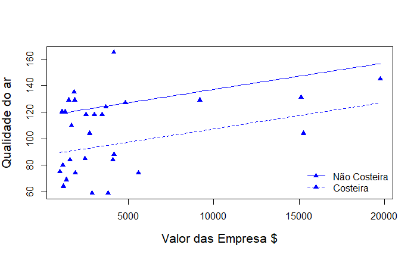

```r
curve(1.171e+02+  1.999e-03*x+-2.968e+01,lty =2, add = TRUE,col='blue', lwd =1.4) # cidade costeira
legend("bottomright",c('Não Costeira', 'Costeira'),pch=17,lty=c(1,2), bty="n", col=c('blue','blue'))
```

### Conclusão

O que afeta a qualidade do ar nas cidades?

As variáveis que afetaram foram: (a) valor das empresa e (b) a posição das cidades.

Quanto maior o valor das empresa, pior a qualidade do ar. Cidades costeiras apresentam uma melhor qualidade.